# Overtake.GP · Anàlisi de dades

## Estructura del notebook

| Bloc | Contingut |
| --- | --- |
| **0. Configuració** | Imports, constants, càrrega de dades |
| **1. KPIs i SMART** | Anàlisi descriptiu i verificació d'objectius |
| **2. Impacte d'accions** | Tests estadístics Mann-Whitney |
| **3. Anàlisi de continguts** | Formats, hores, correlacions |
| **4. Benchmarking** | Comparativa amb 6 comptes referents |
| **5. Model predictiu** | Projecció de seguidors (Holt-Winters) |
| **6. Conclusions** | Síntesi dels resultats principals |

> ⚠️ **Actualització pendent · 9 de juny**  
> Reexecutar tot el notebook amb els CSVs actualitzats.  
> El test del GP Catalunya (acreditat) requereix dades fins al 10 de juny.

## Bloc 0 · Configuració i càrrega de dades

Centralitzem aquí tots els imports, constants i càrregues de dades.  
**Sempre executar aquest bloc primer** abans de qualsevol altre.

```python
# ── Imports ────────────────────────────────────────────
import pandas as pd
import numpy as np
from scipy import stats
from sqlalchemy import create_engine
import warnings
warnings.filterwarnings('ignore')
import seaborn as sns
import matplotlib.pyplot as plt

print('Llibreries carregades correctament')
```

```
Llibreries carregades correctament
```

### Constants

Definim aquí totes les constants del projecte: paths, dates clau i paràmetres.  
Si cal actualitzar les dades, només cal modificar aquesta cel·la.

```python
# ── Constants ───────────────────────────────────────────

# Paths dels fitxers de dades
DATA_DIR = ''   # canvia si els CSV estan en una subcarpeta

FITXERS_COMPTES = {
    'overtake'            : 'overtake.gp-historical-stats.csv',
    'everithingmotoracing': 'everythingmotoracing-historical-stats.csv',
    'motociclismo_es'     : 'motociclismo_es-historical-stats.csv',
    'moto_gp'             : 'motogp-historical-stats.csv',
    'motorsportcom'       : 'motorsportcom-historical-stats.csv',
    'motorspain_77'       : 'motospain77-historical-stats.csv',
    'brake_gp'            : 'brake.gp-historical-stats.csv',
}

FITXER_POSTS = 'instagram-posts_2025-05-23_2026-05-23.csv'

# Dates clau del projecte
DATA_INICI_TFG    = '2025-09-01'   # inici periode academic
DATA_INICI_LLARG  = '2024-01-01'   # inici periode llarg benchmarking
DATA_INICI_CURT   = '2024-11-12'   # inici periode curt (brake_gp disponible)

# Connexió MySQL
# TODO: moure a .env abans de pujar a Git
DB_USER     = 'root'
DB_PASSWORD = 'root'
DB_HOST     = '127.0.0.1'
DB_NAME     = 'overtake'

print('Constants definides correctament')
```

```
Constants definides correctament
```

### Càrrega de dades

Carreguem tots els datasets en aquesta secció. La funció `import_csv_comptes` unifica els fitxers dels comptes referents en un sol DataFrame, afegint la columna `account`.

```python
# ── Funció de càrrega ────────────────────────────────────
def import_csv_comptes(diccionari):
    """
    Importa múltiples CSVs amb el mateix format, afegeix la columna 'account'
    i els concatena en un únic DataFrame.

    Paràmetres:
        diccionari (dict): {nom_compte: fitxer_csv}
    Retorna:
        pd.DataFrame: DataFrame unificat amb columna 'account'
    """
    llista = []
    for nom, fitxer in diccionari.items():
        temp = pd.read_csv(DATA_DIR + fitxer)
        temp.columns = temp.columns.str.strip().str.lstrip('\ufeff')
        temp['account'] = nom
        llista.append(temp)
        print(f'  {nom}: {len(temp)} files')
    return pd.concat(llista, ignore_index=True)


# ── Dataset 1: comptes comparatius (InstaTrack) ───────────
print('Carregant comptes...')
df_comptes = import_csv_comptes(FITXERS_COMPTES)

# ── Dataset 2: posts Overtake.GP (Metricool) ──────────────
print('\nCarregant posts...')
posts = pd.read_csv(DATA_DIR + FITXER_POSTS,
                    sep=';', quotechar='"',
                    on_bad_lines='skip', encoding='utf-8')
posts.columns = posts.columns.str.strip().str.lstrip('\ufeff')
print(f'  posts: {len(posts)} files')

# ── Dataset 3: sèrie temporal Overtake.GP ────────────────
hist = df_comptes[df_comptes['account'] == 'overtake'].copy()

print(f'\nTotal files df_comptes : {len(df_comptes)}')
print(f'Total posts            : {len(posts)}')
print(f'Total dies hist        : {len(hist)}')
```

```
Carregant comptes...
  overtake: 878 files
  everithingmotoracing: 2013 files
  motociclismo_es: 1055 files
  moto_gp: 2775 files
  motorsportcom: 2265 files
  motorspain_77: 1888 files
  brake_gp: 562 files

Carregant posts...
  posts: 394 files

Total files df_comptes : 11436
Total posts            : 394
Total dies hist        : 878
```

```python
# ── Neteja unificada ─────────────────────────────────────

# Conversions de tipus
df_comptes['date'] = pd.to_datetime(df_comptes['date'])
df_comptes['engagement_rate'] = (
    df_comptes['engagement_rate'].str.replace('%','').astype(float)
)
df_comptes['comments_to_likes_ratio'] = (
    df_comptes['comments_to_likes_ratio'].str.replace('%','').astype(float)
)
df_comptes = df_comptes.sort_values(['account','date']).reset_index(drop=True)

# Columnes derivades
df_comptes['daily_gain']    = df_comptes.groupby('account')['followers_count'].diff()
df_comptes['posts_per_day'] = df_comptes['weekly_posts'] / 7
df_comptes['month']         = df_comptes['date'].dt.to_period('M')
df_comptes['growth_rate']   = (
    df_comptes['daily_gain'] /
    df_comptes['followers_count'].replace(0, np.nan) * 100
)

# Posts: conversions de tipus
posts['Timestamp'] = pd.to_datetime(posts['Timestamp'])
for col in ['Engagement','Likes','Views','Reach (Organic)',
            'Saved','Comments','Shares','Interactions']:
    posts[col] = pd.to_numeric(
        posts[col].astype(str).str.replace(',','.'), errors='coerce'
    )
posts['hour']     = posts['Timestamp'].dt.hour
posts['weekday']  = posts['Timestamp'].dt.day_name()
posts['month']    = posts['Timestamp'].dt.to_period('M')
posts['hour_bin'] = pd.cut(posts['hour'],
                            bins=[0,6,10,13,17,21,24],
                            labels=['0-6h','7-10h','11-13h','14-17h','18-21h','22-24h'])

# Sèrie temporal Overtake (actualitzada amb columnes derivades)
hist = df_comptes[df_comptes['account'] == 'overtake'].copy().reset_index(drop=True)

# Subconjunts per benchmarking
df_llarg = df_comptes[
    (df_comptes['date'] >= DATA_INICI_LLARG) &
    (df_comptes['account'] != 'brake_gp')
].copy()
df_llarg['index_100'] = df_llarg.groupby('account')['followers_count'].transform(
    lambda x: x / x.iloc[0] * 100
)

df_curt = df_comptes[df_comptes['date'] >= DATA_INICI_CURT].copy()
df_curt['index_100'] = df_curt.groupby('account')['followers_count'].transform(
    lambda x: x / x.iloc[0] * 100
)

print('Neteja i transformacions completades')
print(f'  df_comptes : {len(df_comptes):,} files')
print(f'  df_llarg   : {len(df_llarg):,} files · {df_llarg["account"].nunique()} comptes')
print(f'  df_curt    : {len(df_curt):,} files · {df_curt["account"].nunique()} comptes')
print(f'  hist       : {len(hist):,} files')
print(f'  posts      : {len(posts):,} posts')
```

```
Neteja i transformacions completades
  df_comptes : 11,436 files
  df_llarg   : 5,265 files · 6 comptes
  df_curt    : 3,931 files · 7 comptes
  hist       : 878 files
  posts      : 394 posts
```

```python
# ── Connexió MySQL ───────────────────────────────────────
# TODO: substituir per variables d'entorn (.env) abans de pujar a Git
engine = create_engine(
    f'mysql+pymysql://{DB_USER}:{DB_PASSWORD}@{DB_HOST}/{DB_NAME}',
    pool_size=5, pool_recycle=3600, echo=False
)

# Exportem tots els DataFrames a MySQL
for nom, df in [
    ('comptes',      df_comptes),
    ('comptes_llarg', df_llarg),
    ('comptes_curt',  df_curt),
]:
    df.to_sql(nom, con=engine, if_exists='replace', index=False)
    print(f'  MySQL · taula "{nom}" actualitzada ({len(df):,} files)')
```

```
  MySQL · taula "comptes" actualitzada (11,436 files)
  MySQL · taula "comptes_llarg" actualitzada (5,265 files)
  MySQL · taula "comptes_curt" actualitzada (3,931 files)
```

## Bloc 1 · Anàlisi descriptiu i KPIs

### Fonts de dades

Per a aquesta anàlisi fem servir dos datasets complementaris:

- **InstaTrack** · seguiment diari del compte des del 31 de desembre de 2023 fins a l'actualitat. Inclou 7 comptes del sector del motociclisme amb un total de ~11.000 registres. S'utilitza per als KPIs basats en evolució temporal de seguidors i freqüència de publicació.
- **Metricool** · registre individual de publicacions des de maig de 2025 fins a l'actualitat, amb informació de més de 380 posts. S'utilitza per al KPI d'engagement, que requereix dades a nivell de post individual.

### Objectius SMART verificats

| # | Objectiu | Mètrica | Font | Llindar |
| --- | --- | --- | --- | --- |
| SMART 1 | Creixement de seguidors set-25 → jun-26 | % increment followers | InstaTrack | ≥ 25% |
| SMART 2 | Seguidors per publicació | daily_gain / posts_per_day | InstaTrack | ≥ 15 seg/post |
| SMART 3 | Freqüència de publicació | posts_per_day | InstaTrack | ≥ 1 post/dia |
| SMART 4 | Taxa d'engagement per post | Engagement (%) | Metricool | > 5% |

```python
# ── Verificació objectius SMART ──────────────────────────

# SMART 1: creixement set-25 → avui
seg_set25  = hist[hist['date'] >= DATA_INICI_TFG]['followers_count'].iloc[0]
seg_avui   = hist['followers_count'].iloc[-1]
smart1     = (seg_avui / seg_set25 - 1) * 100

# SMART 2: seguidors per publicació (aproximació)
# Nota metodològica: cap eina registra conversió directa a seguidors per post.
# S'aproxima dividint el guany total de seguidors pel nombre de publicacions.
periode    = hist[hist['date'] >= DATA_INICI_TFG].copy()
guany_total = periode['followers_count'].iloc[-1] - periode['followers_count'].iloc[0]
total_posts = periode['posts_per_day'].sum()
smart2      = guany_total / total_posts

# SMART 3: posts per dia
smart3 = hist[hist['date'] >= DATA_INICI_TFG]['posts_per_day'].mean()

# SMART 4: engagement mitjà per post
smart4 = posts['Engagement'].mean()

# Taula de resultats
print('=' * 55)
print(f'{"KPI":<12} {"Valor real":>12} {"Objectiu":>12} {"Resultat":>10}')
print('=' * 55)
print(f'{"SMART 1":<12} {smart1:>11.1f}% {"≥ 25%":>12} {"✅" if smart1>=25 else "❌":>10}')
print(f'{"SMART 2":<12} {smart2:>11.1f}  {"≥ 15 seg":>12} {"✅" if smart2>=15 else "❌":>10}')
print(f'{"SMART 3":<12} {smart3:>11.2f}  {"≥ 1.0":>12} {"✅" if smart3>=1 else "❌":>10}')
print(f'{"SMART 4":<12} {smart4:>11.1f}% {"> 5%":>12} {"✅" if smart4>5 else "❌":>10}')
print('=' * 55)
```

```
=======================================================
KPI            Valor real     Objectiu   Resultat
=======================================================
SMART 1             38.0%        ≥ 25%          ✅
SMART 2             20.7      ≥ 15 seg          ✅
SMART 3             1.34         ≥ 1.0          ✅
SMART 4             10.2%         > 5%          ✅
=======================================================
```

## Resultats · Objectius SMART

Tots quatre objectius SMART s'han assolit durant el període setembre 2025 – juny 2026:

Els resultats de SMART 2 i SMART 4 són especialment significatius perquè reflecteixen no només creixement en volum, sinó qualitat de la interacció amb l'audiència — un indicador clau de la sostenibilitat del projecte a llarg termini.

## Bloc 2 · Anàlisi d'impacte d'accions estratègiques

En aquest bloc volem demostrar si les accions dutes a terme durant el projecte han tingut un impacte estadísticament significatiu en el creixement diari de seguidors d'Overtake.GP.

Analitzem tres esdeveniments clau:

1. **Pic viral · juny 2024** → +711 seguidors en un dia
2. **Inici TFG · setembre 2025** → professionalització del compte
3. **GP Catalunya · maig 2026** → cobertura presencial acreditada

Per a cada esdeveniment comparem el creixement diari en una finestra de **30 dies abans i 30 dies després**. S'han escollit 30 dies perquè és un període prou ampli per capturar l'efecte sostingut d'una acció, sense incorporar altres esdeveniments que podrien contaminar l'anàlisi.

**Hipòtesi nul·la (H₀):** l'esdeveniment no ha produït cap canvi significatiu en el creixement diari de seguidors.

**Test:** Mann-Whitney U. No assumeix distribució normal i compara medianes en lloc de mitjanes, més robust davant pics i outliers propis de les dades de xarxes socials. Considerem estadísticament significatiu un **p-valor < 0.05**.

```python
# ── Definició d'esdeveniments i finestra temporal ────────
FINESTRA = 30  # dies

esdeveniments = [
    {'nom': 'Pic viral juny 2024',      'data': '2024-06-04'},
    {'nom': 'Inici TFG setembre 2025',  'data': '2025-09-01'},
    {'nom': 'GP Catalunya maig 2026',   'data': '2026-05-01'},
]

# Mostrem les finestres abans/després per a cada esdeveniment
for e in esdeveniments:
    d = pd.Timestamp(e['data'])
    abans   = hist[(hist['date'] >= d - pd.Timedelta(days=FINESTRA)) &
                   (hist['date'] <  d)]['daily_gain'].dropna()
    despres = hist[(hist['date'] >= d) &
                   (hist['date'] <  d + pd.Timedelta(days=FINESTRA))]['daily_gain'].dropna()
    print(f"\n{'='*45}")
    print(f"{e['nom']}")
    print(f"  Abans  → n={len(abans):2d} · mediana={abans.median():.1f} · std={abans.std():.1f}")
    print(f"  Després→ n={len(despres):2d} · mediana={despres.median():.1f} · std={despres.std():.1f}")
```

```
=============================================
Pic viral juny 2024
  Abans  → n=30 · mediana=40.5 · std=38.5
  Després→ n=30 · mediana=50.0 · std=130.3

=============================================
Inici TFG setembre 2025
  Abans  → n=30 · mediana=11.0 · std=27.1
  Després→ n=30 · mediana=14.5 · std=22.1

=============================================
GP Catalunya maig 2026
  Abans  → n=30 · mediana=31.0 · std=29.5
  Després→ n=27 · mediana=31.0 · std=40.9
```

```python
# ── Test Mann-Whitney U ───────────────────────────────────
resultats = []

for e in esdeveniments:
    d = pd.Timestamp(e['data'])
    abans   = hist[(hist['date'] >= d - pd.Timedelta(days=FINESTRA)) &
                   (hist['date'] <  d)]['daily_gain'].dropna()
    despres = hist[(hist['date'] >= d) &
                   (hist['date'] <  d + pd.Timedelta(days=FINESTRA))]['daily_gain'].dropna()

    stat, pval = stats.mannwhitneyu(abans, despres, alternative='two-sided')

    if   pval < 0.001: sig = '*** (p<0.001)'
    elif pval < 0.01:  sig = '**  (p<0.01)'
    elif pval < 0.05:  sig = '*   (p<0.05)'
    else:              sig = 'ns  (no significatiu)'

    resultats.append({
        'Esdeveniment'   : e['nom'],
        'Mediana abans'  : round(abans.median(), 1),
        'Mediana després': round(despres.median(), 1),
        'Diferència'     : round(despres.median() - abans.median(), 1),
        'p-valor'        : round(pval, 4),
        'Significació'   : sig,
    })

df_resultats = pd.DataFrame(resultats)
print(df_resultats.to_string(index=False))
```

```
           Esdeveniment  Mediana abans  Mediana després  Diferència  p-valor          Significació
    Pic viral juny 2024           40.5             50.0         9.5   0.4332 ns  (no significatiu)
Inici TFG setembre 2025           11.0             14.5         3.5   0.2834 ns  (no significatiu)
 GP Catalunya maig 2026           31.0             31.0         0.0   0.7431 ns  (no significatiu)
```

## Resultats · Test Mann-Whitney U

Cap dels tres esdeveniments analitzats supera el llindar de significació estadística (p < 0.05), de manera que no es pot rebutjar la hipòtesi nul·la amb les dades actuals.

Aquest resultat té dues explicacions complementàries:

**Alta variabilitat intrínseca:** el creixement diari d'Overtake.GP presenta desviacions estàndard molt elevades (fins a 130 seguidors/dia en el període post-viral), cosa que redueix la potència estadística del test i dificulta detectar diferències significatives entre períodes.

**Creixement sostingut vs. impacte puntual:** el patró de creixement d'Overtake.GP és consistent al llarg de tot el període, sense ruptures clares atribuïbles a esdeveniments concrets. Això suggereix que l'impacte de les accions és acumulatiu i estructural, no puntual.

## Bloc 3 · Anàlisi de continguts

1. Quin format funciona millor? → Imatge vs Carrusel
2. Quin dia de la setmana té més engagement?
3. Quina franja horària és millor per publicar?
4. Quins són els posts més exitosos i per què?
5. Hi ha correlació entre likes, shares i engagement?

```python
# Quins formats tenim i quants posts de cada tipus?
print(posts['type'].value_counts())
print()

# Engagement mitjà per format
print(posts.groupby('type')['Engagement'].agg(['mean','median','count']).round(2))
```

[output not shown]

```python
# Mapejem els noms tècnics a etiquetes llegibles
posts['format'] = posts['type'].map({
    'FEED_IMAGE'          : 'Imatge',
    'FEED_CAROUSEL_ALBUM' : 'Carrusel'
})

# Verifiquem
print(posts['format'].value_counts())
```

```
format
Imatge      321
Carrusel     73
Name: count, dtype: int64
```

```python
# ── Test Mann-Whitney: Imatge vs Carrusel ─────────────
img = posts[posts['format'] == 'Imatge']['Engagement'].dropna()
car = posts[posts['format'] == 'Carrusel']['Engagement'].dropna()

stat, pval = stats.mannwhitneyu(img, car, alternative='two-sided')

print(f"Imatge   → mediana: {img.median():.2f}% · n={len(img)}")
print(f"Carrusel → mediana: {car.median():.2f}% · n={len(car)}")
print(f"\np-valor: {pval:.4f}")
print(f"Significatiu (p<0.05): {'Sí ✅' if pval < 0.05 else 'No ❌'}")
```

```
Imatge   → mediana: 9.66% · n=321
Carrusel → mediana: 10.26% · n=73

p-valor: 0.0444
Significatiu (p<0.05): Sí ✅
```

## Anàlisi per format · Imatge vs Carrusel

El test Mann-Whitney U confirma que els carrusels obtenen un engagement significativament superior a les imatges (mediana 10.26% vs 9.66%, p = 0.044).

Cal interpretar aquest resultat amb cautela per dues raons:

- **Mostra reduïda:** els carrusels representen només 73 dels 394 posts analitzats. Una mostra més gran permetria conclusions més robustes.
- **p-valor just al llindar:** amb p = 0.044, el resultat supera el llindar de significació (p < 0.05) però per un marge estret. Resultats propers al llindar s'interpreten com a tendència, no com a evidència contundent.

Tot i això, la tendència és consistent i estadísticament significativa. Des d'un punt de vista editorial, les dades suggereixen que incrementar la proporció de carrusels podria millorar l'engagement global del compte.

```python
# Engagement per dia de la setmana

ordre = ['Monday','Tuesday','Wednesday','Thursday','Friday','Saturday','Sunday']

etiquetes = ['Dilluns','Dimarts','Dimecres','Dijous','Divendres','Dissabte','Diumenge']

resum_dies = posts.groupby('weekday')['Engagement'].agg(

    ['median','mean','count']

).reindex(ordre).round(2)

resum_dies.index = etiquetes

print(resum_dies)
```

```
           median   mean  count
Dilluns      9.62  10.19     53
Dimarts      9.45  10.05     44
Dimecres    10.07  10.76     42
Dijous      10.26  10.56     45
Divendres    8.97   9.48     61
Dissabte     9.72   9.91     76
Diumenge    10.27  10.78     73
```

```python
# ── Test Kruskal-Wallis: engagement per dia ───────────
grups = [
    posts[posts['weekday'] == dia]['Engagement'].dropna()
    for dia in ordre
]

stat, pval = stats.kruskal(*grups)

print(f"Kruskal-Wallis: stat={stat:.3f} · p-valor={pval:.4f}")
print(f"Significatiu (p<0.05): {'Sí ✅' if pval < 0.05 else 'No ❌'}")
```

```
Kruskal-Wallis: stat=6.235 · p-valor=0.3974
Significatiu (p<0.05): No ❌
```

## Anàlisi per dia de la setmana

Per comparar l'engagement entre més de dos grups utilitzem el test Kruskal-Wallis, l'equivalent de Mann-Whitney per a múltiples categories.

**Hipòtesi nul·la:** l'engagement és igual independentment del dia de publicació.

El test retorna p = 0.397, molt per sobre del llindar de significació (p < 0.05). No es pot rebutjar la hipòtesi nul·la — les diferències observades entre dies no són estadísticament significatives.

Tot i això, les medianes mostren una tendència consistent amb el calendari esportiu del motociclisme:

- **Diumenge (10.27%)** i **Dijous (10.26%)** lideren l'engagement
- **Divendres (8.97%)** obté el resultat més baix
- Els pics coincideixen amb els dies de cursa (diumenge) i d'inici d'entrenaments (dimecres-dijous)

Aquesta tendència no és estadísticament demostrable amb la mostra actual, però és coherent amb el comportament esperat de l'audiència. Amb una mostra més gran podria confirmar-se. Com a hipòtesi de treball, s'aconsella prioritzar les publicacions en aquests dies, sense desatendre la resta.

```python
# Distribució de posts per franja horària
posts['hour_bin'] = pd.cut(
    posts['hour'],
    bins=[0, 6, 10, 13, 17, 21, 24],
    labels=['0-6h','7-10h','11-13h','14-17h','18-21h','22-24h']
)

resum_hores = posts.groupby('hour_bin', observed=True)['Engagement'].agg(
    ['median','mean','count']
).round(2)

print(resum_hores)
```

```
          median   mean  count
hour_bin
0-6h        9.28   9.28      2
7-10h      10.76  10.78     26
11-13h      9.97   9.95     59
14-17h      9.60  10.21    260
18-21h      9.91  10.18     40
22-24h     10.91  10.58      6
```

```python
# ── Test Kruskal-Wallis: engagement per franja horària ──
franges = ['0-6h','7-10h','11-13h','14-17h','18-21h','22-24h']

grups_hores = [
    posts[posts['hour_bin'] == f]['Engagement'].dropna()
    for f in franges
]

stat, pval = stats.kruskal(*grups_hores)

print(f"Kruskal-Wallis: stat={stat:.3f} · p-valor={pval:.4f}")
print(f"Significatiu (p<0.05): {'Sí ✅' if pval < 0.05 else 'No ❌'}")
```

```
Kruskal-Wallis: stat=1.375 · p-valor=0.9271
Significatiu (p<0.05): No ❌
```

```python
# ── Reagrupament en 3 franges ─────────────────────────
posts['hour_bin3'] = pd.cut(
    posts['hour'],
    bins=[0, 12, 18, 24],
    labels=['Matí (0-12h)', 'Tarda (12-18h)', 'Nit (18-24h)']
)

resum_3franges = posts.groupby('hour_bin3', observed=True)['Engagement'].agg(
    ['median', 'mean', 'count']
).round(2)

print(resum_3franges)

# Test Kruskal-Wallis amb les noves franges
grups3 = [
    posts[posts['hour_bin3'] == f]['Engagement'].dropna()
    for f in ['Matí (0-12h)', 'Tarda (12-18h)', 'Nit (18-24h)']
]

stat, pval = stats.kruskal(*grups3)
print(f"\nKruskal-Wallis: stat={stat:.3f} · p-valor={pval:.4f}")
print(f"Significatiu (p<0.05): {'Sí ✅' if pval < 0.05 else 'No ❌'}")
```

```
                median   mean  count
hour_bin3
Matí (0-12h)      9.79  10.04     59
Tarda (12-18h)    9.66  10.26    307
Nit (18-24h)      9.99  10.06     27

Kruskal-Wallis: stat=0.024 · p-valor=0.9879
Significatiu (p<0.05): No ❌
```

## Anàlisi per franja horària

S'han realitzat dos tests Kruskal-Wallis amb granularitats diferents:

- **6 franges** (p = 0.927) → no significatiu
- **3 franges** (p = 0.988) → no significatiu

En tots dos casos, la hipòtesi nul·la — que l'hora de publicació no té rellevància estadística sobre l'engagement — queda àmpliament respaldada.

**Limitació de la mostra:** el 78% dels posts s'han publicat en franja de tarda (12-18h), cosa que desvirtua la comparativa entre franges i redueix la potència estadística del test.

**Limitació geogràfica:** el compte té una audiència distribuïda globalment — Indonesia representa el 28% dels seguidors, seguida d'Espanya (10%), França (6%) i Itàlia (6%). Analitzar l'hora de publicació en hora local espanyola introdueix un biaix important, ja que no reflecteix l'hora de l'audiència real.

Una anàlisi més rigorosa requeriria convertir l'hora de publicació a UTC i creuar-la amb els fusos horaris dels seguidors per país, ponderant per volum d'audiència. Les dades actuals disponibles no permeten aquesta aproximació.

```python
# Top 10 posts per engagement
top10_eng = posts.nlargest(10, 'Engagement')[
    ['Timestamp','format','Engagement','Likes','Views','Content']
].copy()
top10_eng['Content'] = top10_eng['Content'].str[:60]
top10_eng['Timestamp'] = top10_eng['Timestamp'].dt.strftime('%d/%m/%y')

print("=== TOP 10 · ENGAGEMENT ===")
print(top10_eng.to_string(index=False))

# Top 10 posts per views
top10_views = posts.nlargest(10, 'Views')[
    ['Timestamp','format','Views','Engagement','Content']
].copy()
top10_views['Content'] = top10_views['Content'].str[:60]
top10_views['Timestamp'] = top10_views['Timestamp'].dt.strftime('%d/%m/%y')

print("\n=== TOP 10 · VISUALITZACIONS ===")
print(top10_views.to_string(index=False))
```

```
=== TOP 10 · ENGAGEMENT ===
Timestamp   format  Engagement  Likes  Views                                                        Content
 17/01/26 Carrusel       27.13   6646  50450     Back to 2016 🔙😌\n\n#motogp #moto #motorsport #racing #2016
 24/11/25   Imatge       26.69  15389 142430 Max Verstappen has it clear. 🐜🦁\n \nAnd you? Which athlete do
 10/12/25   Imatge       25.79   4651  43507   Fernando Alonso lauded Marc Márquez's spectacular return to
 05/10/25   Imatge       25.05   4025  63912   Since Gresini became an independent team in 2022, five rider
 03/11/25 Carrusel       24.62  18759 500948 These motos are so... 😌\n\n#motogp #moto #motorsport #racing #
 28/11/25 Carrusel       21.98   2689  46804 A glimpse inside their minds 💭✨\n\n#motogp #moto #motorsport #
 09/03/26   Imatge       21.66   1798  15486   🏅 The Motul Grand Prix of the Netherlands has been named the
 01/03/26   Imatge       20.16   2859  24997   ❌ Things haven't started in the best way for Ducati, as toda
 28/01/26   Imatge       19.85  14198 134569   🐧 In 2023, Marc Márquez chose to believe in himself. He step
 28/09/25   Imatge       19.75  10737 817433   Marc Márquez wins his NINTH World Championship, tying Valent

=== TOP 10 · VISUALITZACIONS ===
Timestamp   format   Views  Engagement                                                        Content
 23/09/25   Imatge 2383356        8.94   These would be the MotoGP Ballon d'Or winners since 2010 acc
 30/09/25   Imatge 1952695       11.61   With his latest title, Marc Márquez becomes the rider with t
 31/10/25 Carrusel  901941        8.30   Nicolò Bulega made his debut in the MotoGP World Championshi
 29/03/26   Imatge  839154       11.01   🚨 According to ‘DIARIO AS’ and other media, Pecco has alread
 28/09/25   Imatge  817433       19.75   Marc Márquez wins his NINTH World Championship, tying Valent
 27/08/25   Imatge  816358       12.88   According to ChatGPT, these are the four eras of MotoGP that
 16/10/25   Imatge  815649        7.08   Even though Marquez may miss the rest of the season, as rumo
 26/09/25   Imatge  764019       10.34 🚨 BREAKING NEWS 🚨\n\nDiogo Moreira will be a Honda rider, as c
 12/11/25 Carrusel  613300       19.20 These motos are so... pt.2 😌\n\n#motogp #moto #motorsport #rac
 23/11/25 Carrusel  597566        6.21   117 GPs, 1 pole position, 7 podiums and 5 wins make him the
```

## Top posts · Engagement i Visualitzacions

S'analitzen els 10 posts més exitosos en dues dimensions complementàries:

- **Top Engagement:** mesura la connexió emocional amb l'audiència — la proporció d'usuaris que interactuen respecte als que veuen el post.
- **Top Visualitzacions:** mesura l'exposició i la viralitat — quants usuaris únics han vist el contingut.

**Patró en contingut d'alt engagement:** els posts amb major taxa d'interacció corresponen majoritàriament a contingut d'opinió i comparatives ("Back to 2016", "A glimpse inside their minds", "Since Gresini became independent"). Aquest tipus de contingut estimula el debat i la participació activa de l'audiència fidel.

**Patró en contingut d'alt reach:** les notícies de gran impacte (títol mundial de Márquez, fitxatges, classificacions) generen molta exposició però un engagement relatiu menor, ja que arriben a usuaris nous que no necessàriament segueixen el compte.

**Perfil de l'audiència:** la presència de Max Verstappen (F1) al top 2 d'engagement indica que l'audiència d'Overtake.GP s'interessa pel motor en general, no exclusivament pel motociclisme. Això obre una oportunitat d'expansió editorial cap a altres disciplines del motor sense perdre la identitat central del compte.

**Recomanació editorial:** combinar notícies d'impacte per maximitzar el reach amb contingut d'opinió i comparatives per mantenir l'engagement de l'audiència fidel.

```python
# Correlació entre mètriques de rendiment
correlacions = posts[['Likes','Comments','Shares','Saved',
                       'Views','Engagement']].corr(method='spearman')
print(correlacions.round(3))
```

```
            Likes  Comments  Shares  Saved  Views  Engagement
Likes       1.000     0.796   0.760  0.957  0.880       0.301
Comments    0.796     1.000   0.726  0.801  0.682       0.196
Shares      0.760     0.726   1.000  0.781  0.592       0.304
Saved       0.957     0.801   0.781  1.000  0.870       0.273
Views       0.880     0.682   0.592  0.870  1.000       0.047
Engagement  0.301     0.196   0.304  0.273  0.047       1.000
```

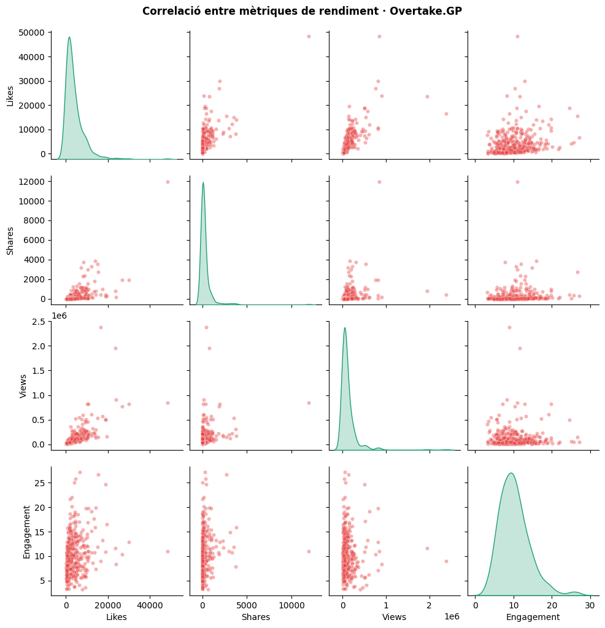

```
Pairplot generat
```

```python
# Seleccionem les variables més rellevants
# Excloem Comments i Saved perquè correlacionen molt amb Likes
# i no afegeixen informació nova
vars_plot = ['Likes', 'Shares', 'Views', 'Engagement']

fig = sns.pairplot(
    posts[vars_plot].dropna(),
    diag_kind='kde',      # diagonal: distribució de cada variable
    plot_kws=dict(alpha=0.4, s=20, color='#E84040'),
    diag_kws=dict(color='#1D9E75')
)

fig.figure.suptitle(
    'Correlació entre mètriques de rendiment · Overtake.GP',
    y=1.02, fontsize=12, fontweight='bold'
)

plt.savefig('fig_pairplot.png', dpi=150, bbox_inches='tight')
plt.show()
print("Pairplot generat")
```

## Bloc 4 · Benchmarking competitiu

### Gestió dels períodes de dades

Per garantir comparatives vàlides, s'han definit dos subconjunts d'anàlisi:

- **Període llarg** (gen. 2024 → mai 2026): inclou tots els comptes excepte Brake.GP. Permet aprofitar la història completa d'Overtake.GP.
- **Període curt** (nov. 2024 → mai 2026): inclou tots els comptes. S'utilitza per a les comparatives que requereixen Brake.GP.

No s'ha procedit a interpolar ni estimar dades per als períodes sense registre, ja que introduiria biaix en l'anàlisi.

```python
# ── Taxa de creixement relativa · resum estadístic ───────

# Període llarg
resum_llarg = df_llarg.groupby('account')['growth_rate'].agg(
    ['mean','median','std','count']
).round(4).sort_values('median', ascending=False)
print('=== CREIXEMENT RELATIU · PERÍODE LLARG (gen 2024 → avui) ===')
print(resum_llarg)

# Període curt
resum_curt = df_curt.groupby('account')['growth_rate'].agg(
    ['median','std','count']
).round(4).sort_values('median', ascending=False)
print('\n=== CREIXEMENT RELATIU · PERÍODE CURT (nov 2024 → avui) ===')
print(resum_curt)
```

```
=== CREIXEMENT RELATIU · PERÍODE LLARG (gen 2024 → avui) ===
                        mean  median     std  count
account
overtake              0.2014  0.1021  0.3695    877
motorspain_77         0.0662  0.0302  0.1260    877
motorsportcom         0.0316  0.0246  0.0412    878
moto_gp               0.0202  0.0141  0.0389    878
motociclismo_es       0.0679  0.0137  0.2887    877
everithingmotoracing  0.0083  0.0046  0.0371    878

=== CREIXEMENT RELATIU · PERÍODE CURT (nov 2024 → avui) ===
                      median     std  count
account
overtake              0.0862  0.1617    561
brake_gp              0.0585  0.0727    561
motociclismo_es       0.0374  0.1103    561
motorspain_77         0.0349  0.1091    561
motorsportcom         0.0267  0.0420    562
moto_gp               0.0096  0.0403    562
everithingmotoracing  0.0009  0.0405    562
```

```python
# ── Índex base 100 · trajectòria acumulada ───────────────
print('=== ÍNDEX BASE 100 · PERÍODE LLARG ===')
print(df_llarg.groupby('account')['index_100'].agg(['first','last']).round(1))

print('\n=== ÍNDEX BASE 100 · PERÍODE CURT ===')
print(df_curt.groupby('account')['index_100'].agg(['first','last']).round(1))
```

```
=== ÍNDEX BASE 100 · PERÍODE LLARG ===
                      first   last
account
everithingmotoracing  100.0  107.5
moto_gp               100.0  119.4
motociclismo_es       100.0  182.1
motorspain_77         100.0  178.7
motorsportcom         100.0  132.0
overtake              100.0  586.5

=== ÍNDEX BASE 100 · PERÍODE CURT ===
                      first   last
account
brake_gp              100.0  148.3
everithingmotoracing  100.0  101.8
moto_gp               100.0  108.6
motociclismo_es       100.0  147.5
motorspain_77         100.0  144.3
motorsportcom         100.0  122.1
overtake              100.0  202.8
```

## Interpretació comparativa: períodes llarg i curt

Overtake.GP lidera la taxa de creixement relatiu diari en els dos períodes analitzats, confirmant el seu dinamisme de forma consistent.

La reducció de la mediana entre el període llarg (0.10%) i el curt (0.08%) és esperada i s'explica per l'**efecte de saturació relativa**: a mesura que augmenta la base de seguidors, cada nou seguidor representa una fracció menor del total, reduint matemàticament el creixement percentual.

La desviació estàndard d'Overtake segueix sent la més alta del conjunt (0.161 en període curt), consistent amb la major sensibilitat d'un compte de mida reduïda als pics de creixement puntuals i continguts virals.

## Bloc 5 · Model predictiu

> 🔲 **Pendent de desenvolupament**

## Bloc 6 · Conclusions

> 🔲 **Pendent de desenvolupament**